# Child Doc 5: Food Consumption

Grace Rubin

2025-01-17

## 2.d. Overview

Because our data collection plan included regular fasts, the easiest and most useful way for us to quantify and visualize and quantify food consumption is via total food consumption, rather than daily food consumption (over 24 hour periods).

## 2.d.i. Total Food Consumption Across Treatment Groups

To start, I’m going to plot the total food consumption of each mouse individually with a trend line. This will help us see the extent of variation in our data and point out any possible errors.

### Food Consumption in Each Indiviudal Mouse

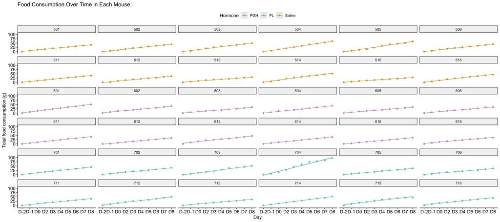

Mouse 704 is weird and needs to be filtered out!

For the next visualization, I’m going to create a faint line for each individual mouse, plus a thicker group average.

### Food Consumption Across Hormone Groups

First I’ll group just by hormone, *NOT* considering ABX status:

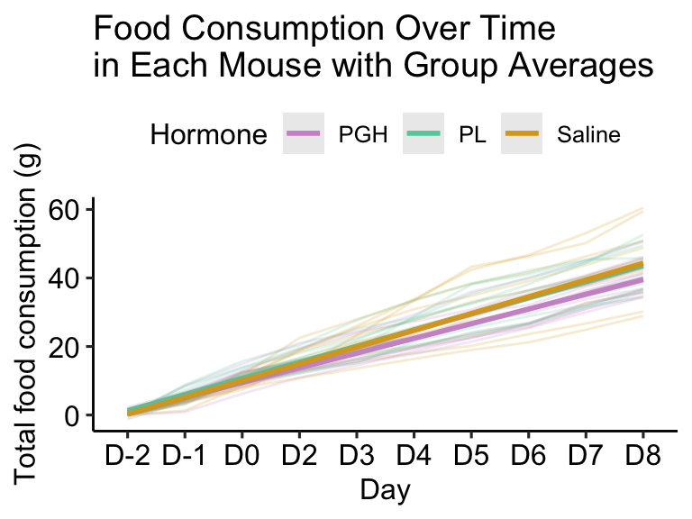

PGH mice potentially consuming less food?

Now I’ll split the above into ABX and Non-ABX and see if that alters paterns:

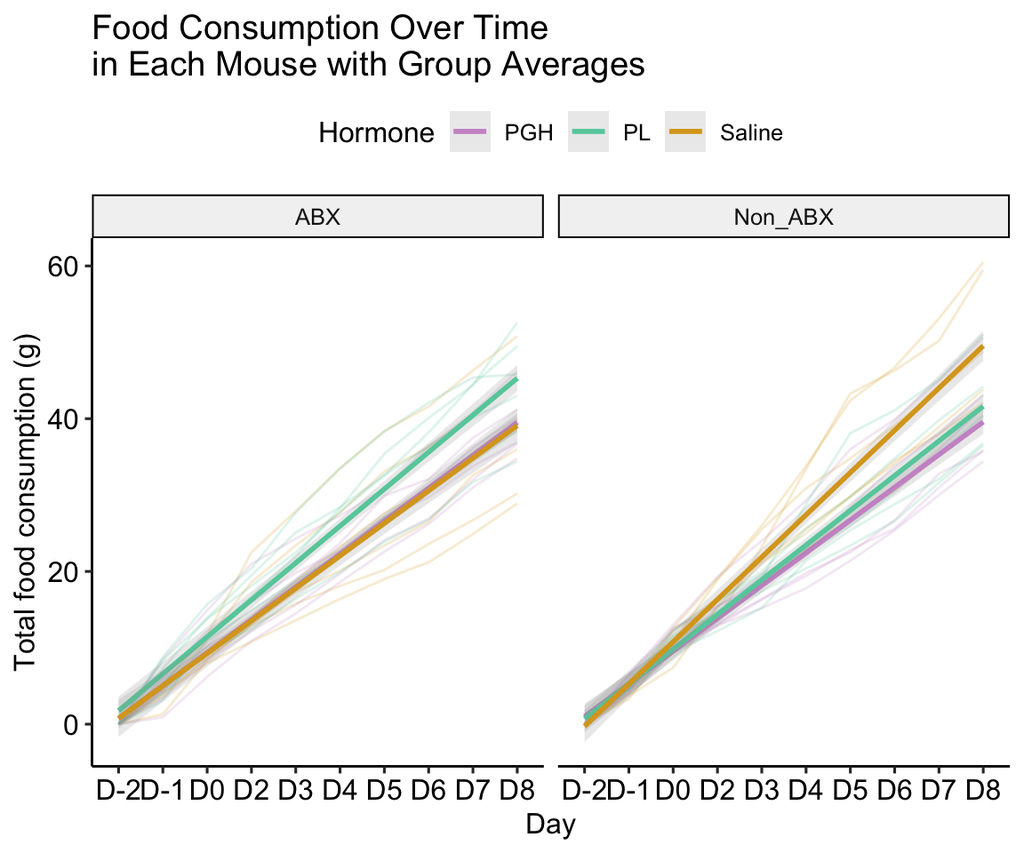

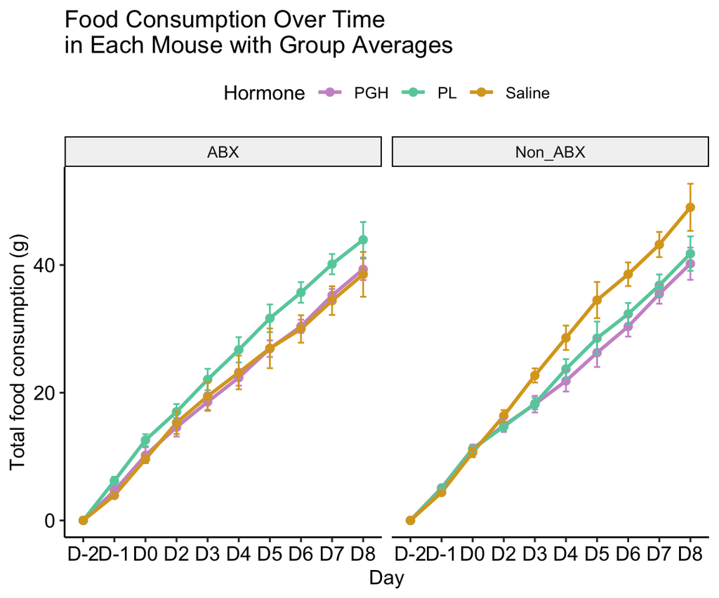

Interesting! Potentially an interaction effect between ABX and hormone status.

### Food Consumption Across Antibiotic Groups

Next I’ll group just by ABX, *NOT* considering hormone status:

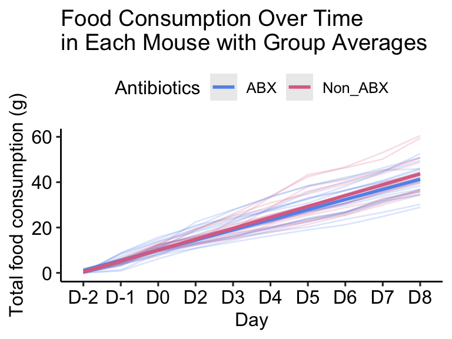

No obvious difference between groups, and lots of noise.

Now let’s compare ABX and non-ABX mice within the same hormone group:

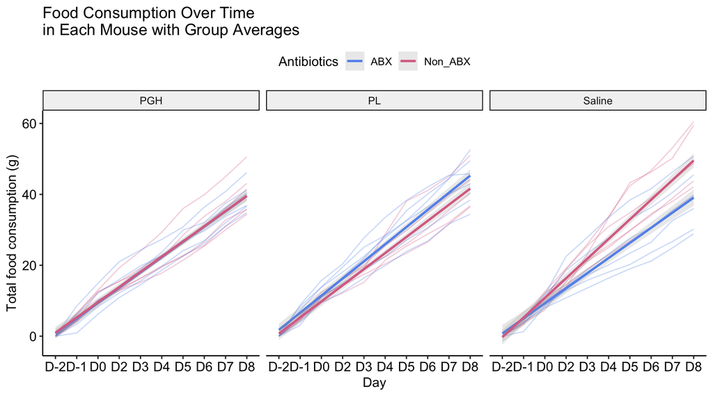

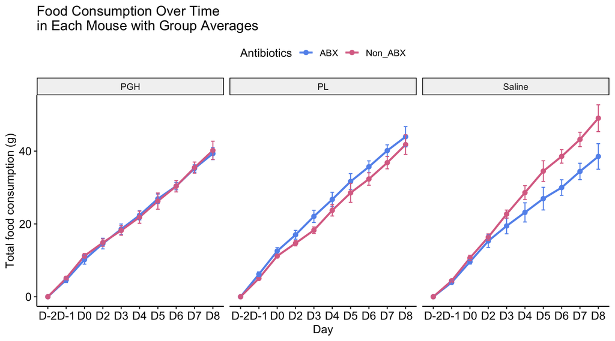

Hm! Group seeing the largest effect of ABX is saline!

*NOTE: I believe in style 1, the shading around the line is showing the confidence interval, not standard error. The second format shows actual standard error.*

### Food Consumption Rate Statistical Testing

**The outputs for these models are super long, so I’m just going to summmarize. Explore the child docs for the full outputs!**

Now I’m gonna test if there’s a significant difference between the slopes of these food consumption lines for each group.

- I will start with comparing the rate of food consumption in PGH and PL mice to Saline mice within the Non-ABX groups:

**Recap of results:** From Day 4 onward (to Day 8), the slopes of the food consumption lines for PGH and PL both significantly differ from the slope of the Saline line, indicating a reduced rate of food consumption in the hormone-injected non-abx mice.

- And now comparing the rate of food consumption in PGH and PL mice to Saline mice within the ABX groups:

**Recap of results:** From day 5 onward (to Day 8), the rate of food consumption (slope) for PL ABX mice is significantly higher than for saline ABX mice. The rate of food consumption (slope) doesn’t significantly differ between saline and PGH ABX mice.

- Next comparing Non-ABX to ABX in the PGH mice (don’t expect significance):

**Recap of results:** The rates of food consumption do not significantly differ in the PGH ABX and Non-ABX mice.

- Next comparing Non-ABX to ABX in the PL mice (don’t expect significance):

**Recap of results:** The rates of food consumption do not significantly differ in the PL ABX and Non-ABX mice. However, certain days (D3, D6, and D7) are approaching significance (0.05 < p < 0.1).

- Next comparing Non-ABX to ABX in the Saline mice (expect significance):

**Recap of results:** From Day 5 onward, the rates of food consumption are significantly higher in the Saline Non-ABX mice than in the ABX mice.

The fact that there is an ABX-based effect in the saline mice but not the PGH or PL mice is interesting!

## 2.d.ii. Food Consumption and Weight Gain.

*NOTE:* I’m not 100% confident that these figures are showing anything worth looking at?

I next investigated the relationship between total weight gain and total food consumption. In other words, what is the relationship between the rate at which each mouse is gaining weight and the rate at which it’s total food consumption is increasing?

- Total weight gain was calculated just by subtracting current weight from weight at D-2 (which was considered baseline for this analysis). The data used to generate these plots starts at D-1, which is why the mice don’t all start at 0 for total weight gain.

### Food Consumption vs Weight Gain Across Hormone Groups

First I will see if the relationship differs across hormone groups:

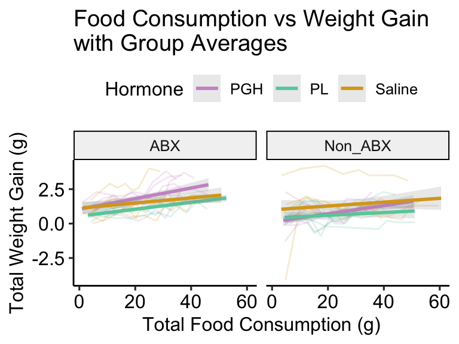

### Food Consumption vs Weight Gain Across Antibiotic Groups

Next I will see if the relationship differs across antibiotic groups:

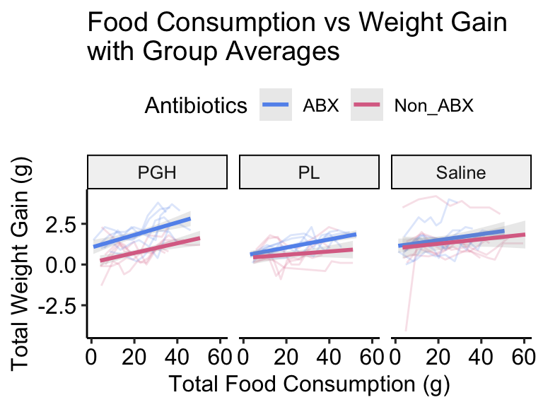

*Takeaway:* It looks like for the same amount of food consumed, ABX PGH mice on average gained more weight than Non-ABX PGH mice. This relationship doesn’t seem to hold for the PL or Saline mice, suggesting that it’s not simply driven by cecal enlargement.

*NOTE:* These weights are not accounting for / subtracting cecum mass.

### Food Consumption vs Weight Gain Statistical Testing

Verifying visual observation that the hormone group slopes don’t differ:

- None of the hormone slopes significantly differ for Non-ABX with saline as the reference
- For the ABX mice, PGH mice had a significantly different relationship between food consumption and weight gain than saline mice, with PGH mice gaining more weight at a higher rate (i.e., gaining more weight with the same of food consumption).
- There was no significant difference between the slopes for PL and Saline ABX mice.

Does the relationship between food consumption and weight gain significantly differ between Non-ABX and ABX mice in each hormone group?

**PGH:**

Significantly different interaction term of antibiotics for PGH mice.

**PL:**

**Saline:**

No significant interaction term of antibiotics for saline with either model type.

## 2.d.ii. Food Consumption and Weight Gain vs Other Variables

I’m not showing any of the plotting here because they all looked uninteresting and the sample sizes were too low to get any good insights, but for reference, I also looked to see if total food consumption and total weight gain had significant relationships (either overall or in specific groups) with the following:

- Change in lean mass (absolute and percentage) [i.e., did mice that gained more lean mass also gain more weight or eat more?]
- Change in fat mass (absolute and percentage)
- Change in free and total water (absolute and percentage)
- Endpoint ITT AUC
- Endpoint OGTT AUC
- Endpoint fasting blood glucose